# 動差與隨機變數的特徵

## 動差的定義

- \(X\) 是一個隨機變數，則\(X\)的\(n\)次動差(moment)為：

\[\mu_n = E X^n\]

### 為什麼要計算動差？

- 動差是一種描述隨機變數的方法
- 通常會用更有物理意義的特徵來描述隨機變數
  - 他們都是動差的函數

## 範例：變異數

- 如果\(X\)是一個隨機變數，則定義\(X\)的變異數為：

\[Var(X) = E(X - E(X))^2 = E(X^2) - E(X)^2\]

### 為什麼這樣定義變異數？

- \(\mu = E(X)\) 可以最小化 \(L(e) = \sum_{x} P(X = x) (x - e)^2\)
  - \(E(X - e)^2 = \sum_{x} P(X = x) (x - e)^2\)
- 把\(\mu\)帶入得到的就是\(Var(X)\)
- 如果用一個點來描述隨機變數\(X\)，若考慮誤差的定義為\(L(e)\)的話：
  - \(E(X)\) 就是最好的描述\(X\)的值
  - \(Var(X)\)是\(L(e)\)的最小值，是描述\(X\)的變化的值

## 範例

- \(S\) 代表骰一個獨立的公平的骰子
- \(X\) 代表點數

\[P(X = 1) = P(X = 2) = ... = P(X = 6) = \frac{1}{6}\]

- \(E(X) = \sum_{x} x P(X = x) = \frac{21}{6} = 3.5\)
- \(Var(X) = \sum_{x} P(X = x) (x - 3.5)^2 = \frac{17.5}{6}\)
- \(E(X^2) = \frac{91}{6} \Rightarrow E(X^2) - (E(X))^2 = \frac{91}{6} - 3.5^2\)

## 變異數的物理意義

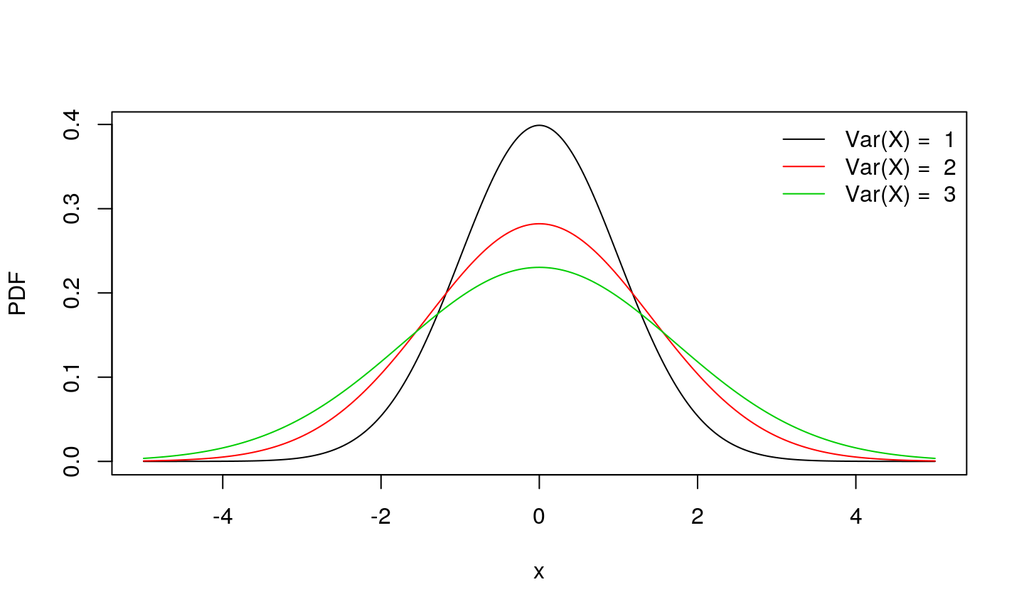

## 變異數的特性

- \(Var(X) = E(E - E(X))^2 = EX^2 - (E(X))^2\)
- \(Var(a X + b) = a^2 Var(X)\)
- 切比雪夫不等式

\[P(| X - E(X) | \geq b) \leq \frac{Var(X)}{b^2}\]

## 範例：偏度(Skewness)

- 令\(\mu = E(X), \sigma^2 = Var(X)\)，則偏度的定義是：

\[E\left(\frac{X - \mu}{\sigma}\right)^3\]

## 偏度

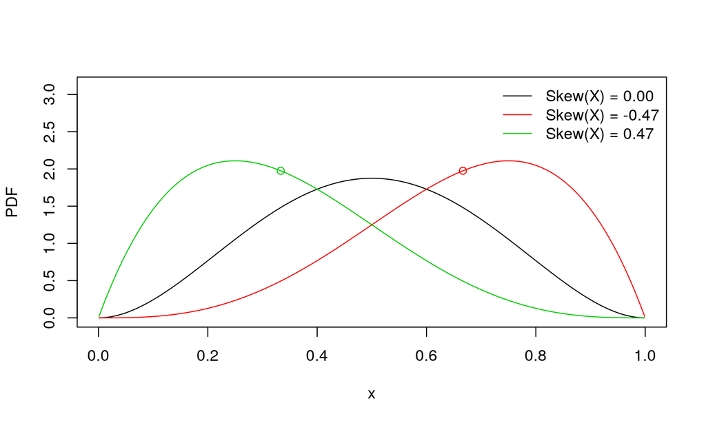

## 重複的動差

- \(X_1\) 的PDF：\(f_1(x) = \frac{1}{\sqrt{2 \pi}x}e^{\frac{-(log(x))^2}{2}}, x \geq 0\)
- \(X_2\) 的PDF：\(f_2(x) = f_1(x) \left(1 + sin(2 \pi log(x))\right), x \geq 0\)
- \(X_1\)與\(X_2\)有完全相同的動差

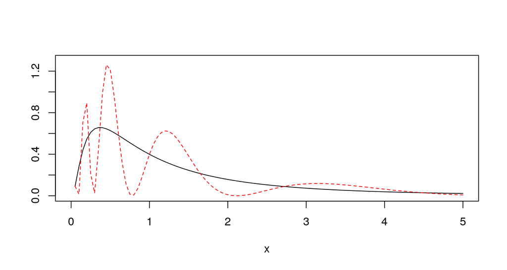